# Time Series Analysis

ChatGPT 4o

2025-01-21

## 1 起源

时间序列分析（Time Series Analysis）起源于20世纪初，用于研究时间随数据变化的规律。George Udny Yule 和 Norbert Wiener等早期研究者在统计学和信号处理领域发展了时间序列理论，特别是在金融和经济学领域得到了广泛应用。20世纪60年代，Box和Jenkins提出了ARIMA模型，标志着现代时间序列分析的蓬勃发展。

## 2 原理

时间序列分析的核心原理是通过研究序列数据的历史趋势和随机成分，来预测未来的值。时间序列分析通常涉及以下几个重要组成部分：

- **趋势（Trend）**：长期方向变化的模式，例如随着时间推移逐渐增加或减少的趋势。
- **季节性（Seasonality）**：周期性变化的模式，通常与固定的时间周期（如每年、每季度）相关。
- **随机成分（Random Component）**：序列中无法解释的噪声或随机波动。

### 2.1 自回归模型（AR）

自回归模型（Autoregressive Model, AR）是一种使用前几个时间点的值来预测当前值的模型。

公式表示为：
$$X_t = c + \phi_1 X_{t-1} + \phi_2 X_{t-2} + \dots + \phi_p X_{t-p} +
\epsilon_t$$
其中：

- $X_t$ 是时间$t$的值。
- $c$ 是常数项。
- $\phi_i$ 是自回归系数。
- $\epsilon_t$ 是随机误差项。

### 2.2 移动平均模型（MA）

移动平均模型（Moving Average Model, MA）通过使用前几个误差项的线性组合来预测当前值。

公式表示为：
$$X_t = \mu + \theta_1 \epsilon_{t-1} + \theta_2 \epsilon_{t-2} + \dots +
\theta_q \epsilon_{t-q} + \epsilon_t$$
其中：

- $\mu$ 是均值。
- $\theta_i$ 是移动平均系数。
- $\epsilon_t$ 是随机误差项。

### 2.3 自回归移动平均模型（ARMA）

自回归移动平均模型（Autoregressive Moving Average Model, ARMA）结合了自回归（AR）和移动平均（MA）成分，用于描述平稳时间序列。

公式表示为：
$$X_t = c + \phi_1 X_{t-1} + \dots + \phi_p X_{t-p} + \theta_1
\epsilon_{t-1} + \dots + \theta_q \epsilon_{t-q} + \epsilon_t$$

### 2.4 自回归积分移动平均模型（ARIMA）

自回归积分移动平均模型（Autoregressive Integrated Moving Average Model, ARIMA）在ARMA模型的基础上加入了差分操作，用于处理非平稳时间序列。

公式表示为：
$$\Delta^d X_t = c + \phi_1 \Delta^{d} X_{t-1} + \dots + \theta_q
\epsilon_{t-q} + \epsilon_t$$
其中：

- $\Delta^d$ 表示差分操作，$d$ 表示差分阶数。

### 2.5 季节性ARIMA（SARIMA）

季节性ARIMA模型（Seasonal ARIMA, SARIMA）是在ARIMA模型的基础上加入季节性成分，用于处理具有季节性变化的时间序列。

公式表示为：
$$X_t = ARIMA(p, d, q) \times (P, D, Q)_m$$
其中：

- $(P, D, Q)_m$ 是季节性参数，$m$ 表示季节周期长度。

## 3 适用范围

时间序列分析适用于以下情况：

- **时间依赖性数据**：当数据随时间变化时，可以使用时间序列分析进行建模，例如经济数据、股票价格、温度变化等。
- **预测未来趋势**：时间序列分析适用于对未来某个时间点的值进行预测。
- **模式识别**：可以识别数据中的长期趋势、周期性变化和随机波动。

## 4 应用情境

时间序列分析在多个领域中有广泛的应用，例如：

- **金融和经济学**：预测股票价格、利率、通货膨胀率、GDP等经济指标。
- **气象学**：用于预测气温、降雨量等天气变化。
- **生产制造**：在生产过程中用于预测需求量、库存控制、设备故障率等。
- **公共卫生**：用于分析疾病的发生率和流行趋势，预测未来疫情的发展。

## 5 优缺点

### 优点

- **预测能力强**：时间序列分析擅长于基于历史数据进行预测，特别是对时间依赖性数据的预测效果较好。
- **捕捉复杂模式**：可以捕捉数据中的长期趋势、季节性变化和随机波动，提供对时间序列的深刻理解。
- **广泛应用**：时间序列分析方法广泛应用于经济、金融、环境和社会科学等领域。

### 缺点

- **对数据要求高**：时间序列分析要求数据有较长的历史记录，如果数据过少，模型的可靠性会降低。
- **模型复杂性高**：构建和选择合适的时间序列模型需要较高的专业知识，且不同模型可能适合不同的数据特征。
- **对非平稳数据敏感**：时间序列分析对非平稳数据非常敏感，通常需要通过差分等方法将其转化为平稳序列。

## 6 在R中的实现及结果解释

在R中，可以使用`forecast`包中的`auto.arima()`函数来进行时间序列建模和预测。以下是一个时间序列分析的实现示例：

```r
# 加载必要的包
library(forecast)
```

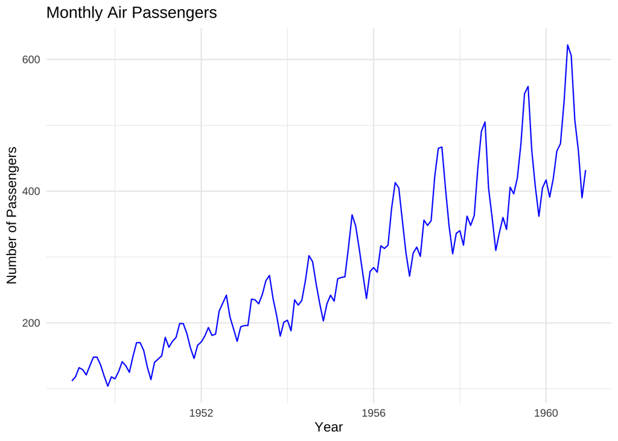

```r
library(ggplot2)

# 示例数据：使用内置的AirPassengers数据集
data <- AirPassengers

# 绘制原始时间序列
ggplot(data.frame(time = as.numeric(time(data)), value = as.numeric(data)), aes(x = time, y = value)) +
  geom_line(color = "blue") +
  labs(title = "Monthly Air Passengers", x = "Year", y = "Number of Passengers") +
  theme_minimal()
```

```r
# 建立ARIMA模型
model <- auto.arima(data)

# 输出模型结果
summary(model)
```

```
## Series: data
## ARIMA(2,1,1)(0,1,0)[12]
##
## Coefficients:
##          ar1     ar2      ma1
##       0.5960  0.2143  -0.9819
## s.e.  0.0888  0.0880   0.0292
##
## sigma^2 = 132.3:  log likelihood = -504.92
## AIC=1017.85   AICc=1018.17   BIC=1029.35
##
## Training set error measures:
##                    ME     RMSE      MAE       MPE     MAPE     MASE
## Training set 1.342306 10.84619 7.867539 0.4206996 2.800458 0.245628
##                      ACF1
## Training set -0.001248451
```

```r
str(model)
```

[output not shown]

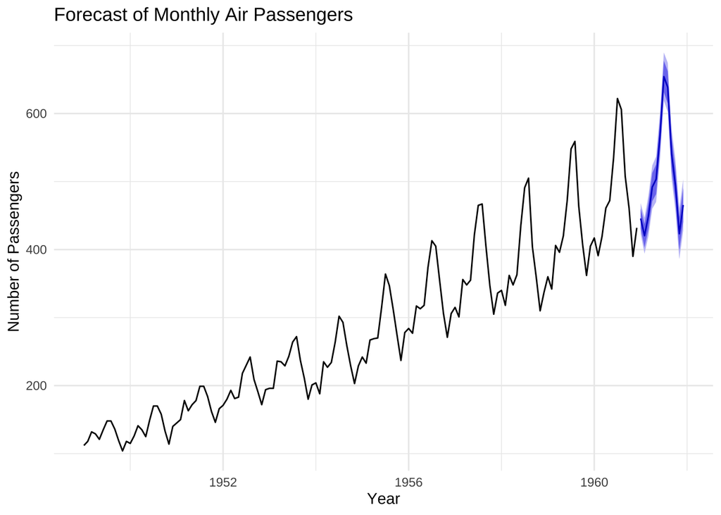

```r
# 进行未来12个月的预测
forecast_result <- forecast(model, h = 12)

# 绘制预测结果
autoplot(forecast_result) +
  labs(title = "Forecast of Monthly Air Passengers", x = "Year", y = "Number of Passengers") +
  theme_minimal()
```

### 结果解释

- **ARIMA模型**：`auto.arima()`函数根据数据的特征自动选择最优的ARIMA模型，包括p、d、q参数。`summary(model)` 输出模型的详细信息，例如自回归和移动平均成分的系数以及模型的AIC值。
- **预测结果**：通过`forecast()`函数对未来12个月的数据进行预测，`autoplot()` 函数用于绘制预测结果，包括预测值和置信区间。该图形展示了未来一年的乘客数量预测以及其不确定性范围。

### 结果的可视化

可以使用`ggplot2`和`forecast`包中的`autoplot()`函数对时间序列及其预测进行可视化，以直观展示原始数据、模型拟合以及未来的预测结果。

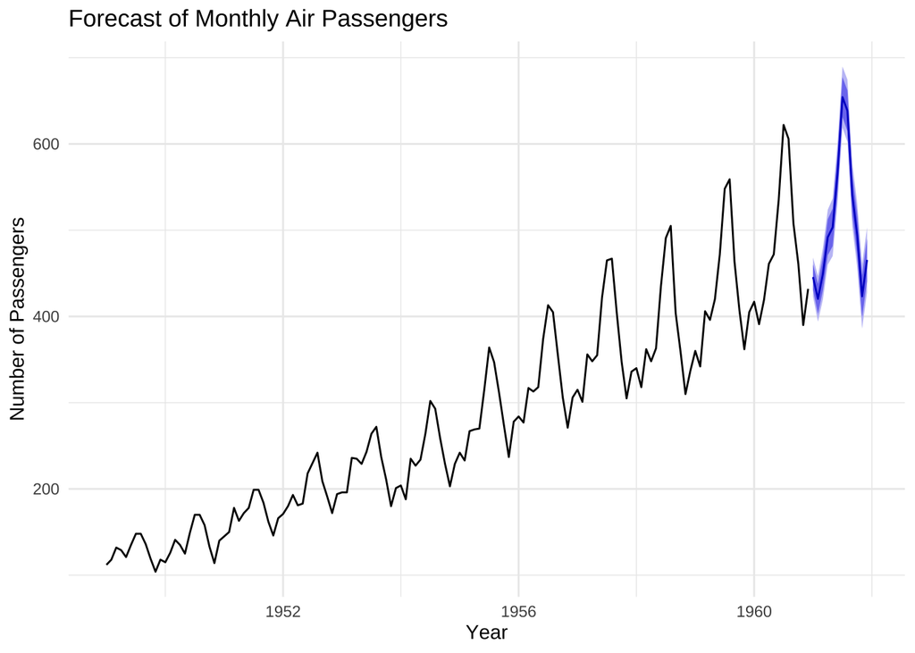

```r
# 绘制预测结果的可视化
autoplot(forecast_result) +
  labs(title = "Forecast of Monthly Air Passengers", x = "Year", y = "Number of Passengers") +
  theme_minimal()
```

上述代码生成预测结果的图形，其中包括原始数据、预测值以及置信区间，便于观察模型的预测效果和未来趋势。

## 7 小结

- 时间序列分析是一种用于分析随时间变化数据的统计方法，广泛应用于金融、经济、环境和社会科学等领域。
- 适用于对时间依赖性数据进行趋势、季节性分析及未来预测。
- 具有预测能力强、可捕捉复杂模式等优点，但对数据要求高，模型选择和构建复杂。
- 可以通过R中的`auto.arima()`函数实现时间序列建模，并结合可视化工具直观展示结果。
- 时间序列分析在理解数据的动态变化及预测未来方面发挥着重要作用，是预测和规划的重要工具。